# WGMEGS 2022 - AEPM: Fecundity and atresia analysis for Atlantic mackerel

mkorta&gcosta

29/03/2023

# Summary

- The realised fecunity for 2022 is 1268 n.g.
- Variances must be calculatd.

# 1 Fishing effort

- Overview of the fishing effort along the time series. Table with Numbers and map.

# 2 Biological sampling

- Overview of the samling effort along the time series. Table with Numbers and map.
- plot Length or weight distribution?

# 3 AEPM Reproductive parameters sampling

## 3.1 Samples (ovaries)

### 3.1.1 Collected

Relation of retained samples by lab and period and screened ones.

| letter | P2 | P3 | P4 | P5 | P6 | P7 | Screened | Retained |
| --- | --- | --- | --- | --- | --- | --- | --- | --- |
| A | 0 | 59 | 0 | 0 | 0 | 0 | 59 | 59 |
| C | 0 | 0 | 202 | 22 | 0 | 17 | 241 | 303 |
| E | 0 | 0 | 0 | 0 | 30 | 0 | 30 | 219 |
| G | 0 | 22 | 101 | 0 | 0 | 0 | 123 | 152 |
| I | 0 | 0 | 0 | 45 | 44 | 0 | 89 | 90 |
| K | 0 | 270 | 0 | 41 | 0 | 0 | 311 | 311 |
| M | 0 | 139 | 246 | 0 | 0 | 0 | 385 | 386 |
| O | 56 | 0 | 0 | 0 | 0 | 0 | 56 | 56 |
| Q | 0 | 0 | 0 | 30 | 0 | 0 | 30 | 30 |
| V | 0 | 6 | 0 | 0 | 0 | 0 | 6 | 7 |
| X | 108 | 271 | 0 | 0 | 0 | 8 | 387 | 387 |
| Total | 164 | 767 | 549 | 138 | 74 | 25 | 1717 | 2000 |

- The objective was to collect 4080 ovaries (4080 AEPM and 3460 DEPM) and in total, 2000 samples were collected, i.e., 2000 AEPM and 1454 DEPM (P3-4-5).
- The objetive was achieved in a 49%.
- 1717 of 2000 were screeened due to diferent reasons.
- Doubt: not sure E001-E030 should be here????

**Geographical distribution**

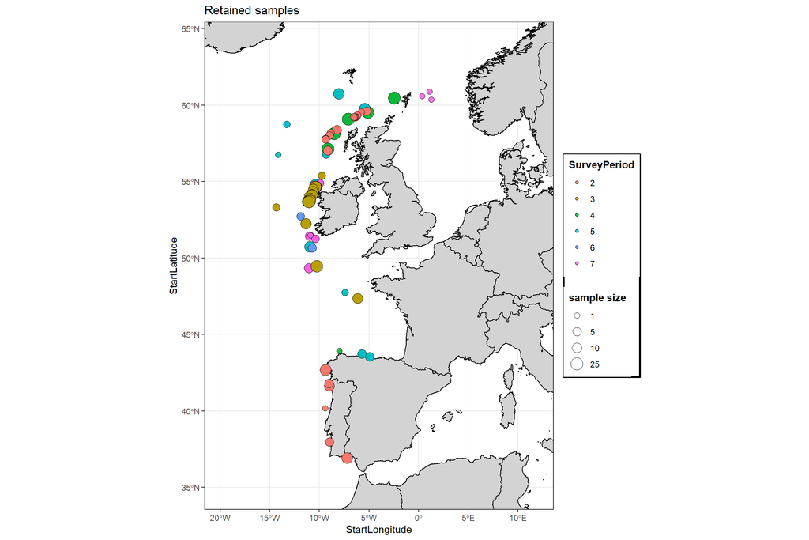

### 3.1.2 Screened

**N Screening samples for fecundity**

Relation of retained samples by lab and period, screened ones and fecundity valid samples.

| letter | P2 | P3 | P4 | P5 | P6 | P7 | Screened | Retained | Scre_Fec_H_Yes | Fec_H_Yes | Fec_W_Yes |
| --- | --- | --- | --- | --- | --- | --- | --- | --- | --- | --- | --- |
| A | 0 | 59 | 0 | 0 | 0 | 0 | 59 | 59 | 42 | 40 | 38 |
| C | 0 | 0 | 202 | 22 | 0 | 17 | 241 | 303 | 38 | 29 | 27 |
| E | 0 | 0 | 0 | 0 | 30 | 0 | 30 | 219 | 0 | 0 | 0 |
| G | 0 | 22 | 101 | 0 | 0 | 0 | 123 | 152 | 25 | 18 | 16 |
| I | 0 | 0 | 0 | 45 | 44 | 0 | 89 | 90 | 4 | 3 | 3 |
| K | 0 | 270 | 0 | 41 | 0 | 0 | 311 | 311 | 64 | 46 | 46 |
| M | 0 | 139 | 246 | 0 | 0 | 0 | 385 | 386 | 19 | 10 | 11 |
| O | 56 | 0 | 0 | 0 | 0 | 0 | 56 | 56 | 15 | 12 | 13 |
| Q | 0 | 0 | 0 | 30 | 0 | 0 | 30 | 30 | 0 | 0 | 0 |
| V | 0 | 6 | 0 | 0 | 0 | 0 | 6 | 7 | 1 | 1 | 1 |
| X | 108 | 271 | 0 | 0 | 0 | 8 | 387 | 387 | 283 | 261 | 254 |
| Total | 164 | 767 | 549 | 138 | 74 | 25 | 1717 | 2000 | 492 | 421 | 411 |

-For AEPM, there are 411 valid samples for fecundity analysis.

**N analysed samples for Prevalence of atresia**

Relation of samples for prevalence of atresia.

| SurveyPeriod | Spawn_H_no | Spawn_H_yes | Spawn_atr_yes |
| --- | --- | --- | --- |
| 2 | 124 | 40 | 5 |
| 3 | 351 | 416 | 146 |
| 4 | 259 | 290 | 66 |
| 5 | 61 | 77 | 12 |
| 6 | 42 | 32 | 10 |
| 7 | 13 | 12 | 4 |
| Total | 850 | 867 | 243 |

Relation of samples for prevalence of atresia by Institute.

| Institute_H | Spawn_H_yes | Spawn_atr_yes | Prevalence |
| --- | --- | --- | --- |
| AZTI | 185 | 53 | 0.2864865 |
| DTU | 177 | 36 | 0.2033898 |
| IEO | 167 | 56 | 0.3353293 |
| IMR | 176 | 61 | 0.3465909 |
| WMR | 162 | 37 | 0.2283951 |
| Total | 867 | 243 | 0.2802768 |

**N analysed samples atresia (intensity)**

| SurveyPeriod | Scre_atr_H_Yes | atr_analysed |
| --- | --- | --- |
| 2 | 5 | 0 |
| 3 | 146 | 57 |
| 4 | 66 | 10 |
| 5 | 12 | 5 |
| 6 | 10 | 1 |
| 7 | 4 | 1 |
| Total | 243 | 74 |

-For AEPM, there are 243 valid samples for atretic intensity analysis, 74 of which were selected by USRS.

### 3.1.3 Structure

**Length and weight distribution of retained samples**

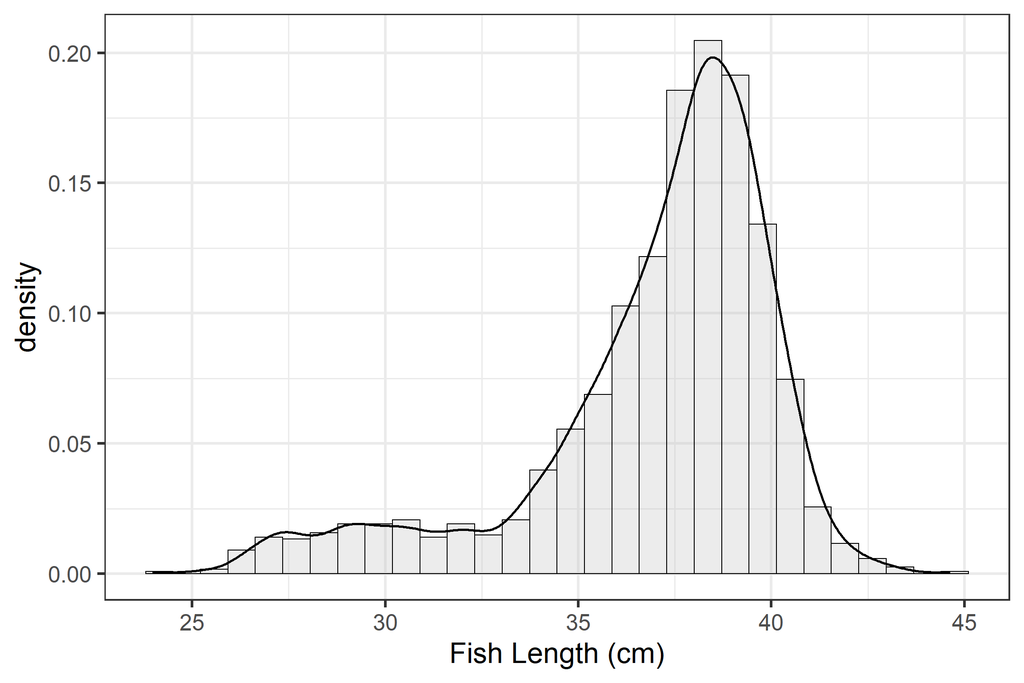

```r
ggplot(scre_bio[!is.na(scre_bio$FishLength),], aes(x=FishLength)) +
  geom_histogram(aes(y=..density..), bins = 30, col="black", alpha=0.3, fill="grey")+
  geom_density(lwd=1)+
  xlab("Fish Length (cm)")
```

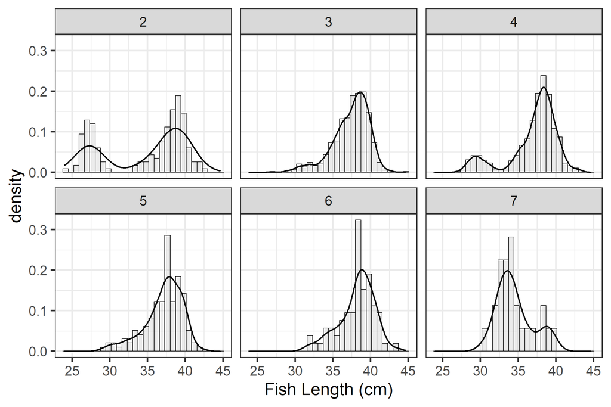

```r
#by period
ggplot(scre[!is.na(scre$FishLength),], aes(x=FishLength, group=SurveyPeriod)) +
  geom_histogram(aes(y=..density..), bins = 30, col="black", alpha=0.3, fill="grey")+
  geom_density(lwd=1)+
  facet_wrap(~SurveyPeriod)+
  xlab("Fish Length (cm)")
```

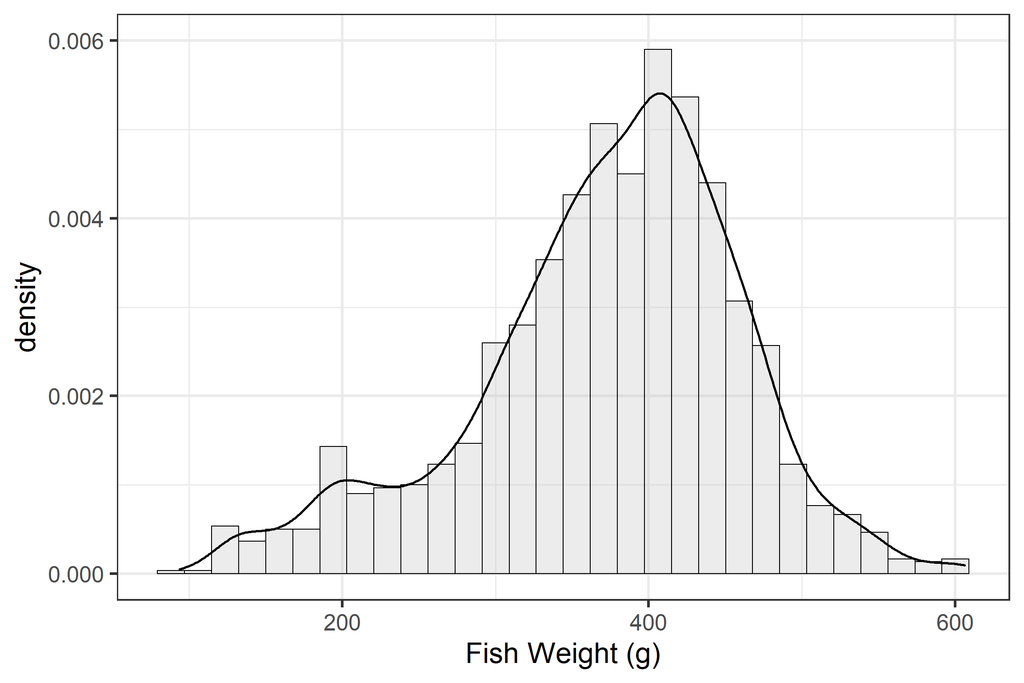

```r
ggplot(scre_bio[!is.na(scre_bio$FishWeight),], aes(x=FishWeight)) +
  geom_histogram(aes(y=..density..), bins = 30, col="black", alpha=0.3, fill="grey")+
  geom_density(lwd=1)+
  xlab("Fish Weight (g)")+
  scale_y_continuous(limits=c(0,0.006))
```

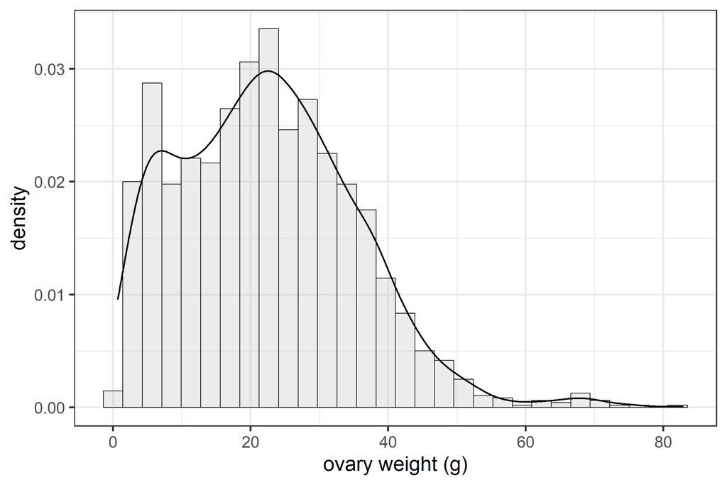

```r
ggplot(scre_bio[!is.na(scre_bio$OvaryWeight),], aes(x=OvaryWeight)) +
  geom_histogram(aes(y=..density..), bins = 30, col="black", alpha=0.3, fill="grey")+
  geom_density(lwd=1)+
  xlab("ovary weight (g)")
```

**Oocyte stage**

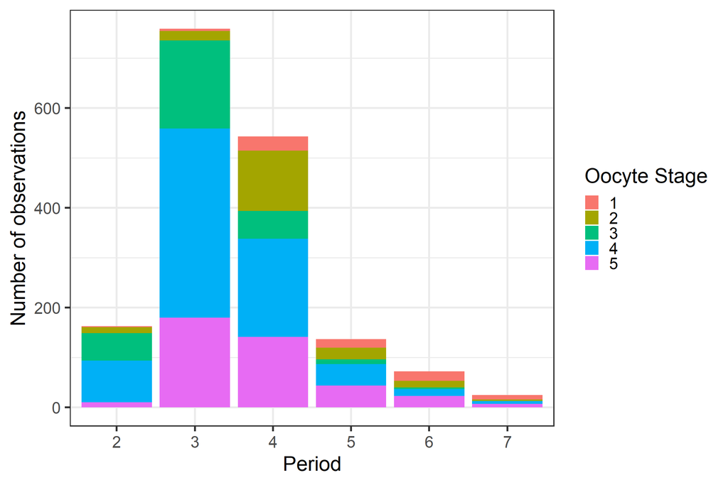

| Oocyte_stage_H | n | percent |
| --- | --- | --- |
| 1 | 79 | 0.0464979 |
| 2 | 192 | 0.1130077 |
| 3 | 300 | 0.1765745 |
| 4 | 723 | 0.4255444 |
| 5 | 405 | 0.2383755 |

**POF**

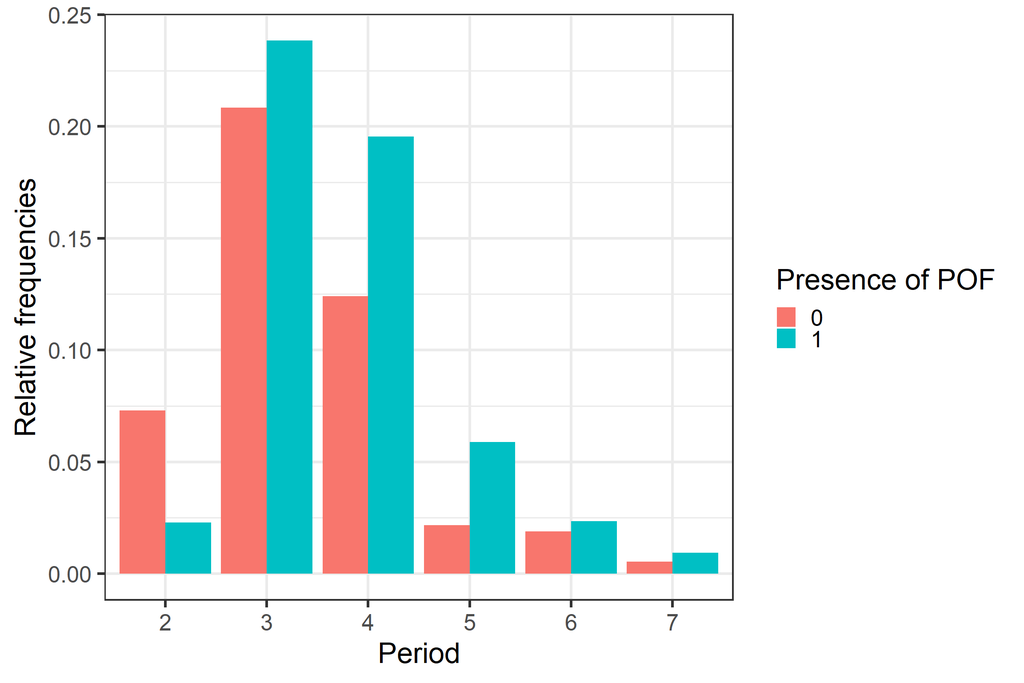

| POF_H | n | percent |
| --- | --- | --- |
| 0 | 767 | 0.451442 |
| 1 | 932 | 0.548558 |

**Maturity**

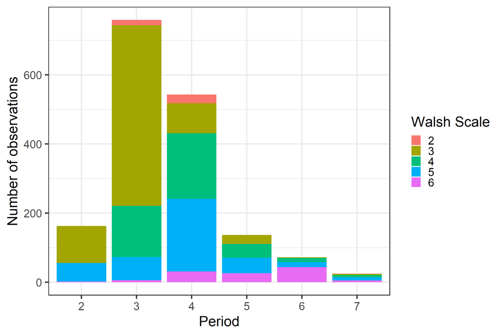

**FULTON’S K**

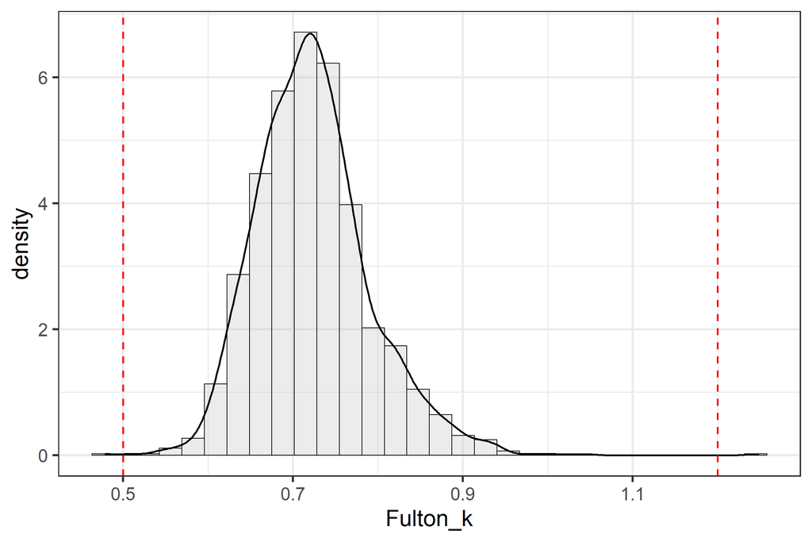

**GSI**

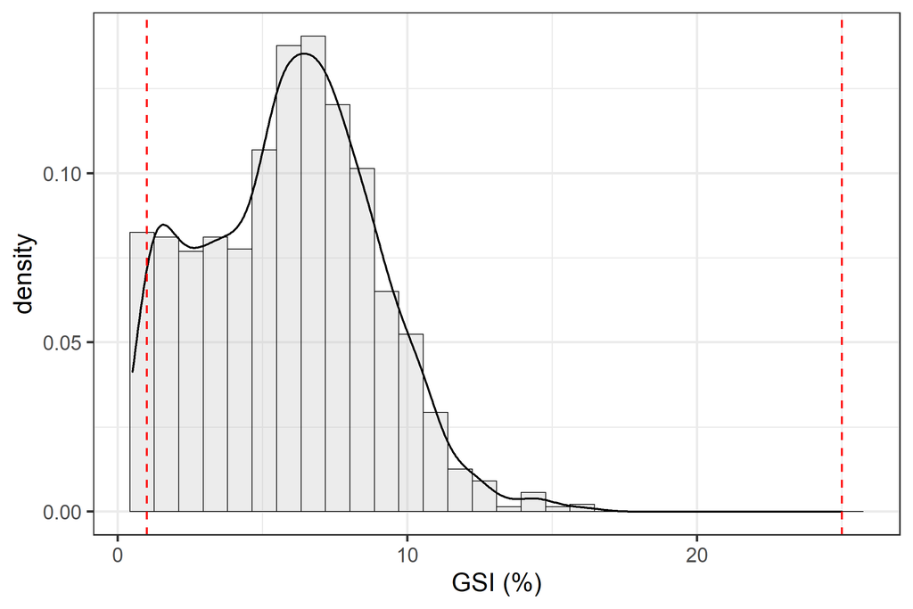

## 3.2 Fecundity

### 3.2.1 Numbers

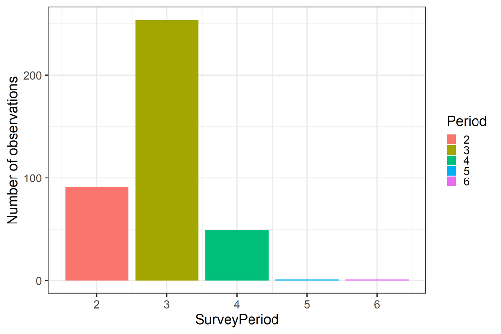

letter

n

DE

G

15

ES

K

42

ES

M

10

GB-SCT

C

26

IE

A

37

NL

I

2

NL

V

1

NL

X

252

PT

O

11

Total

396

396 observation available for fecundity analysis.

Most of the samples belong to period 3.

### 3.2.2 Structure

**Length distribution**

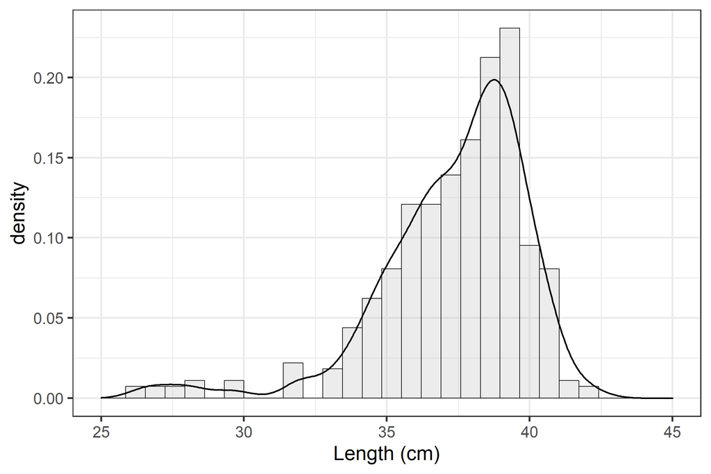

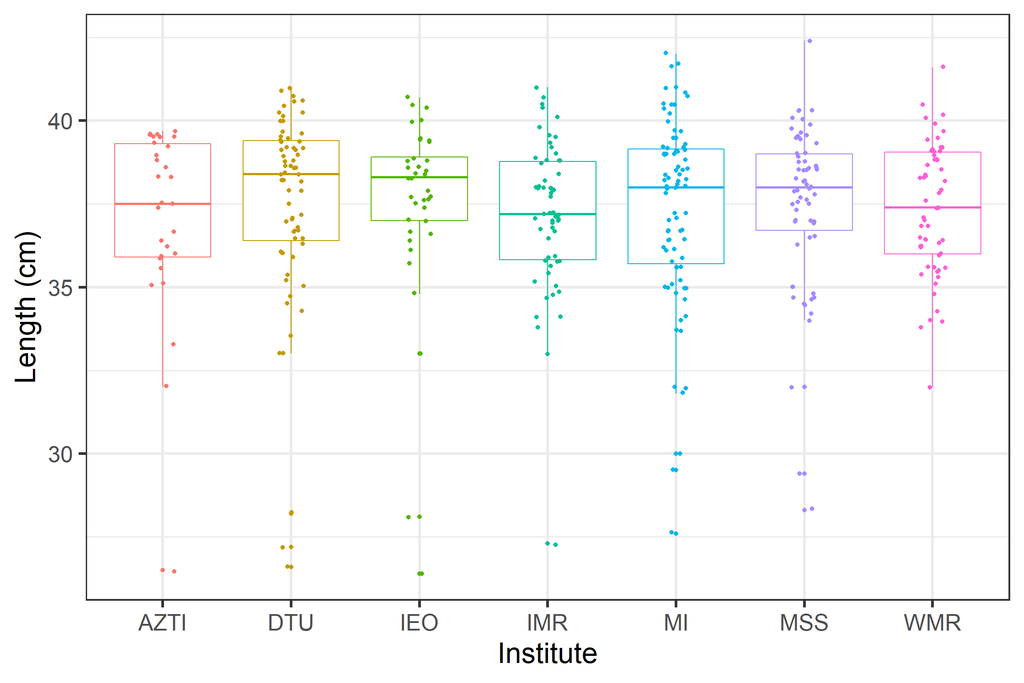

- Low differences in mean fish length among institutes.

**Weight distribution**

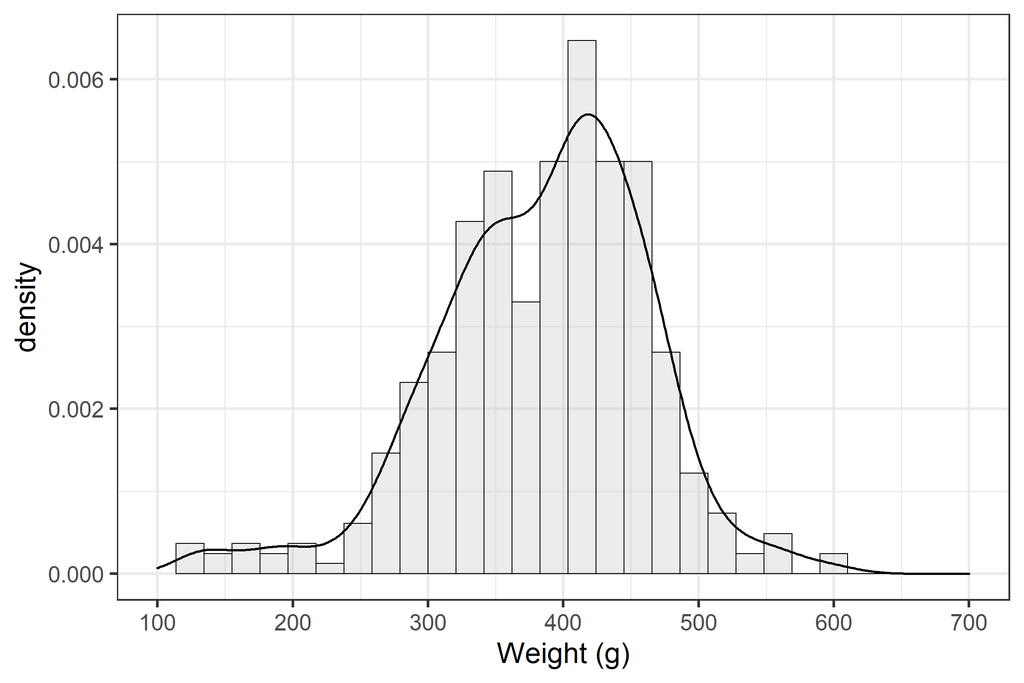

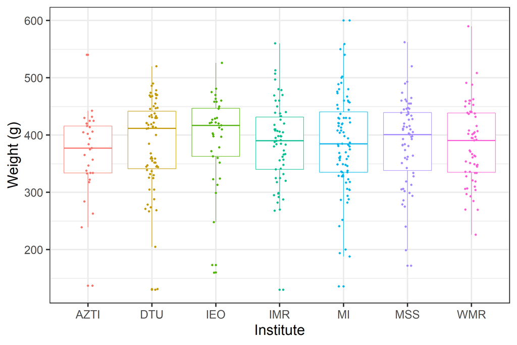

- Low differences in mean fish weight among periods.

```
## [1] 37.34975
```

| SurveyPeriod | count | meanL | meanW |
| --- | --- | --- | --- |
| 2 | 91 | 37.07 | 395.78 |
| 3 | 254 | 37.39 | 379.58 |
| 4 | 49 | 37.65 | 389.30 |
| 5 | 1 | 38.00 | 476.00 |
| 6 | 1 | 37.80 | 397.00 |
| NA | 396 | 37.35 | 384.80 |

**Ovary Weight distribution**

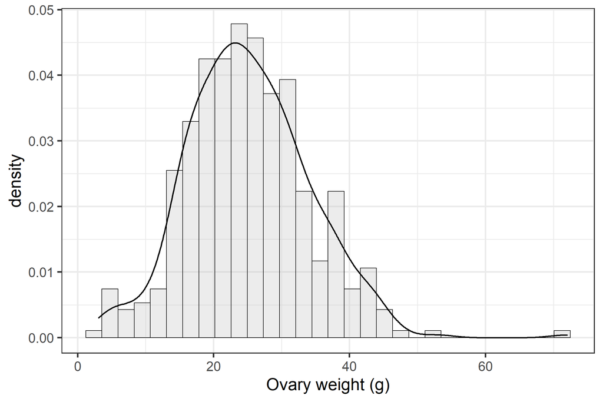

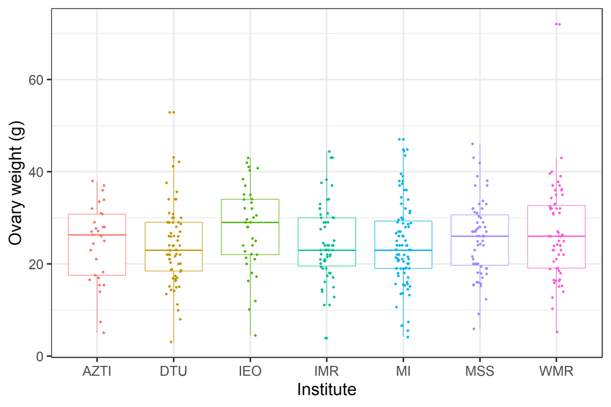

- High ovary weight individuals analysed by WMR.X208 and DTU K012.

**FULTON’S K**

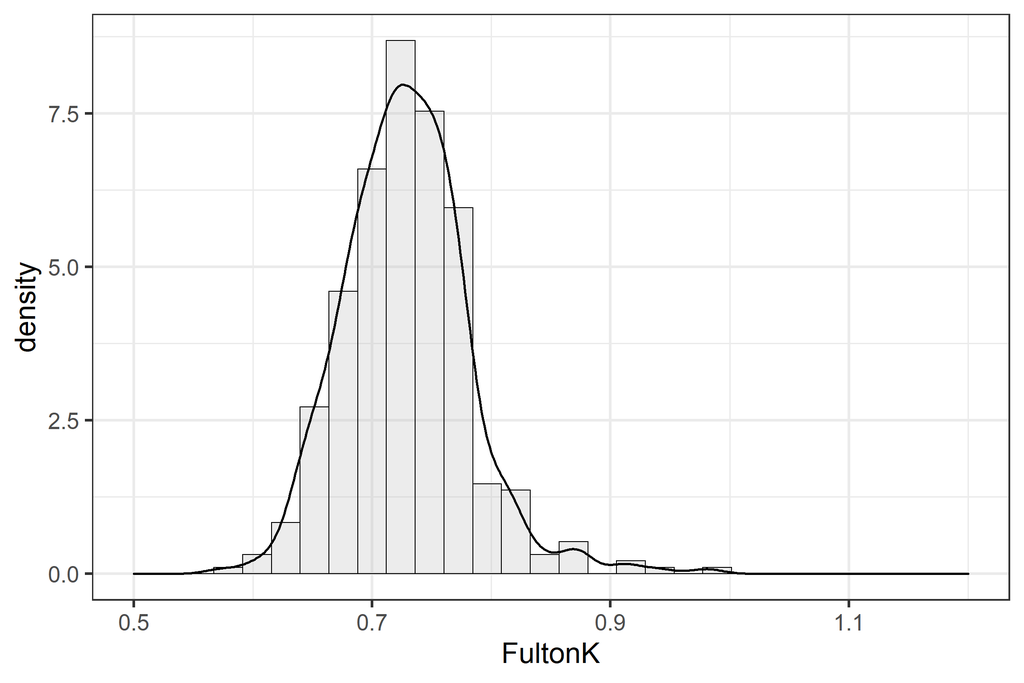

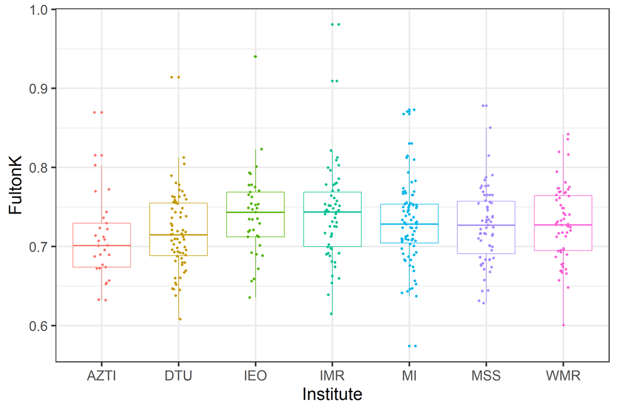

**GSI**

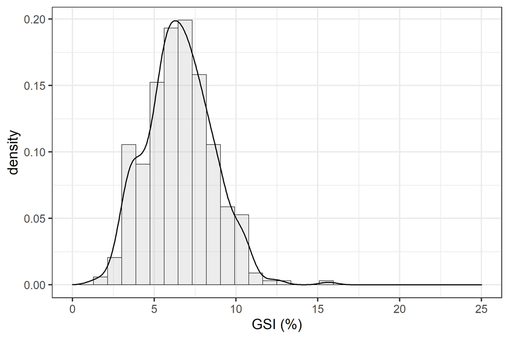

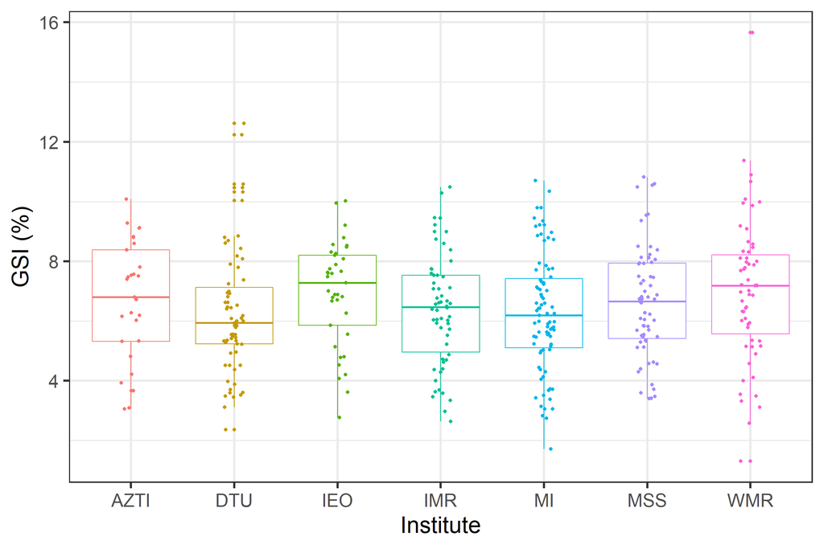

### 3.2.3 Potential Fecundity

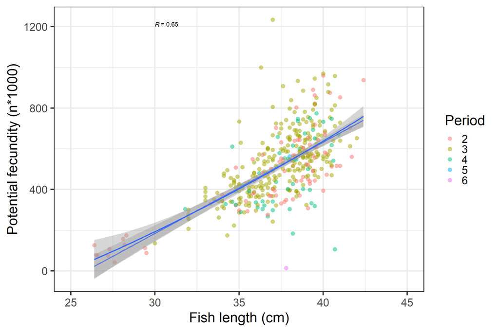

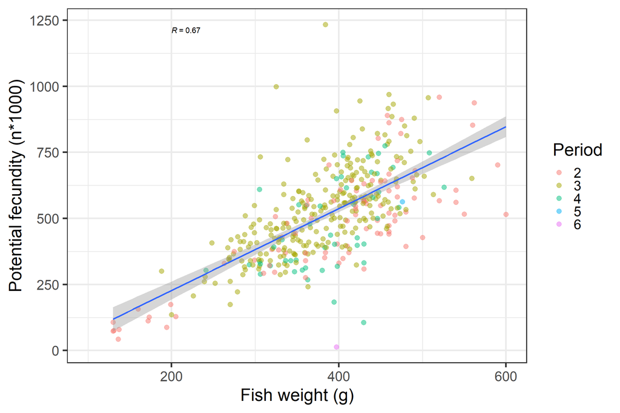

| Fecundity_by | count | median |
| --- | --- | --- |
| AZTI | 29 | 540444.2 |
| DTU | 67 | 566169.2 |
| IEO | 37 | 618450.0 |
| IMR | 58 | 508223.1 |
| MI | 83 | 384000.0 |
| MSS | 63 | 586692.3 |
| WMR | 59 | 450692.3 |

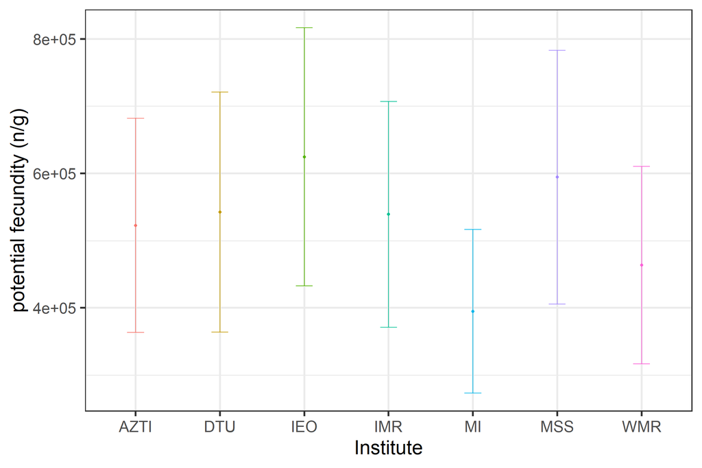

### 3.2.4 Relative potential Fecundity

| Relative potential fecundity count | Relative potential fecundity mean | Relative potential fecundity median | Relative potential fecundity Trimmean10 | Relative potential fecundity sd | Relative potential fecundity max | Relative potential fecundity min | Relative potential fecundity error | Relative potential fecundity left | Relative potential fecundity right |
| --- | --- | --- | --- | --- | --- | --- | --- | --- | --- |
| 396 | 1318.91 | 1313.04 | 1311 | 358.78 | 3212.5 | 34.26 | 35.45 | 1283.46 | 1354.36 |

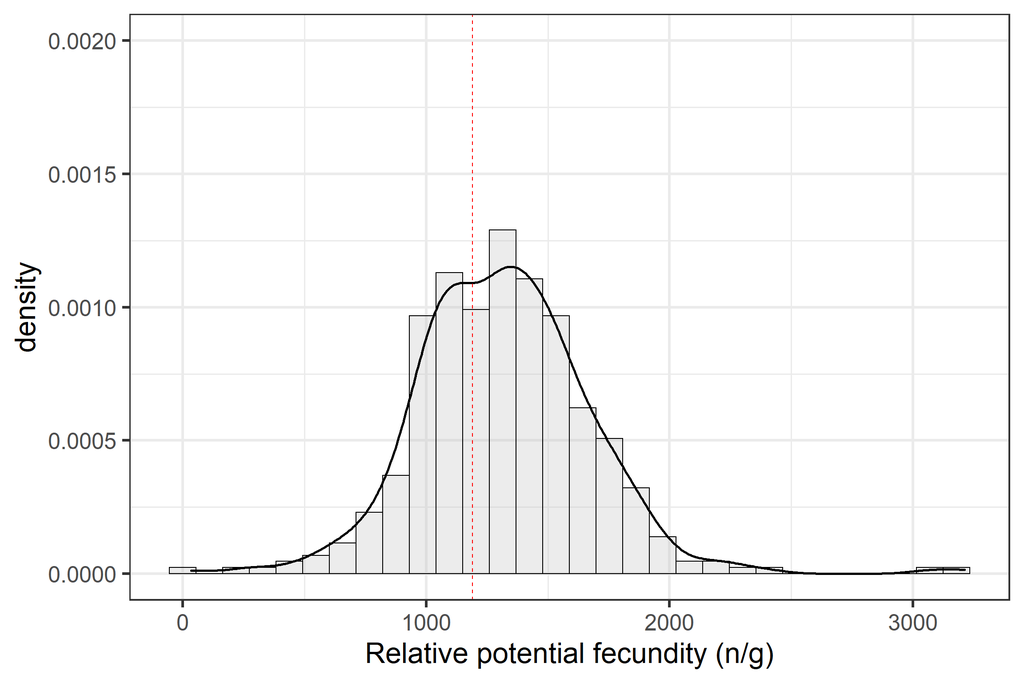

- The median is 1313 ovo/g.

Relative potencial fecundity by Institute

| Fecundity_by | count | median |
| --- | --- | --- |
| AZTI | 29 | 1391.78 |
| DTU | 67 | 1423.92 |
| IEO | 37 | 1601.96 |
| IMR | 58 | 1369.44 |
| MI | 83 | 1026.62 |
| MSS | 63 | 1488.20 |
| WMR | 59 | 1191.29 |

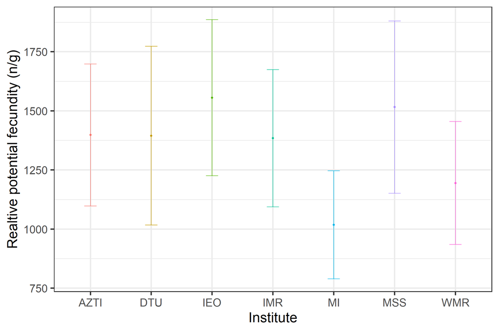

- Slightly lower MI.

**Relative fecundity by lenght and weight**

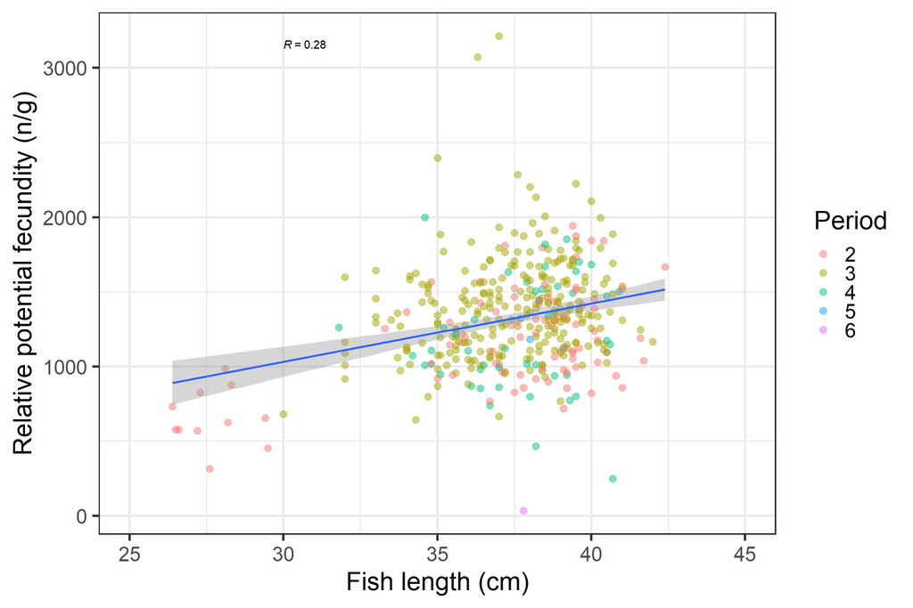

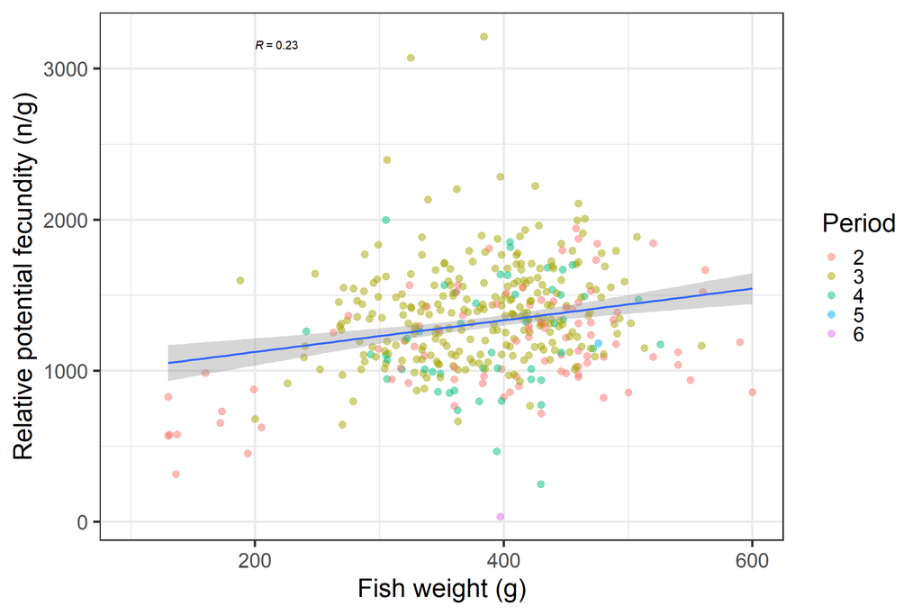

**Relative fecundity latitudinally**

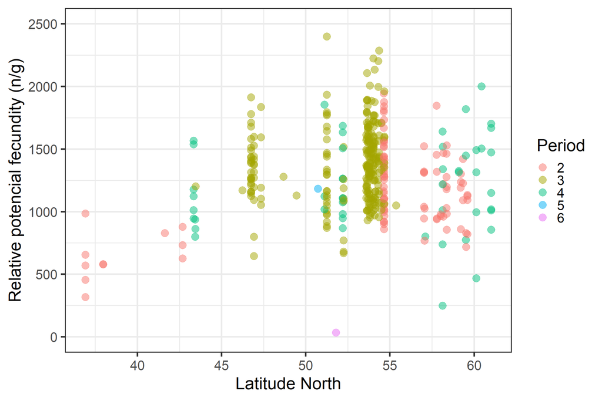

**Relative fecundity calendar Day**

[figure not shown]

**Relative leading cohort diameter**

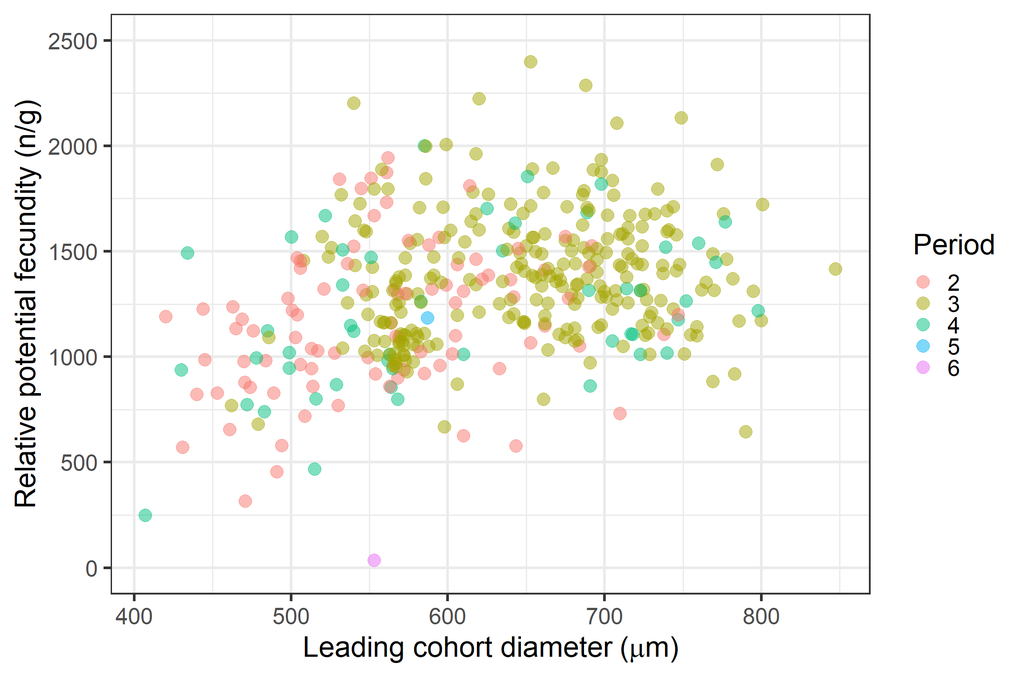